# Assignment 2

#### **Instructor: Prof. Gunnar Heins**

#### **Teaching Assistant: Pedro de Sousa Almeida**

#### Student: C.H.(Chenhui Lu)

#### UFID: 76982846

===============================================================================

### **1 Writing Functions [30 points]**

#### 1. Write a function that tests if a vector x is longer than a vector y or equally long.

```r
rm(list = ls())  # Empty Environment
library("data.table")
Test_longer <- function(x,y){
  length1 <- length(x) # get the length of vector x
  length2 <- length(y) # get the length of vector y
  z <- length1 >= length2 # campare the length
  return(z)
}

#Example
x <- c(1,8,3,4)
y <- c(1,3,9,2,3)
Test_longer(x,y)
```

```
## [1] FALSE
```

It works

#### 2. Write a function that tests if a vector x has more elements that are greater than 5 than a vector y.

```r
Test_bigger_element <- function(x,y){    # set up function
  h <- 0                                 # h is counting number
  for ( i in 1:length(x)) {              # count the number of elements of x which > 5
    if (x[i] > 5) {
      h <- h + 1
    }
  }

 k <- 0                                 # h is counting number
 for (i in 1:length(y)) {               # similarly
   if (y[i] > 5) {
     k <- k + 1
   }
 }

 return(h > k)                         # compare and return
}

#Example 1.
Test_bigger_element(x,y)
```

```
## [1] FALSE
```

```r
#Example 2.
x2 <- c(8,6,5,8,1)
y2 <- c(2,4,5,9)
Test_bigger_element(x2,y2)
```

```
## [1] TRUE
```

It works

#### 3. Write a function with three arguments (x,y, and c, where c is a scalar) that tests if a vector x has more elements that are smaller than c than vector y.

```r
Test_smaller_element <- function(x,y,c){ # set up function
  h <- 0                                 # h is counting factor
  for ( i in 1:length(x)) {              # count the number of elements of x which < c
    if (x[i] < c) {
      h <- h + 1
    }
  }

  k <- 0                                 # h is counting factor
  for (i in 1:length(y)) {               # similarly
    if (y[i] < c) {
      k <- k + 1
    }
  }

  return(h > k)                         # compare and return
}

#Example 1.
Test_smaller_element(x,y,3)
```

```
## [1] FALSE
```

```r
#Example 2.
Test_bigger_element(x2,y2)
```

```
## [1] TRUE
```

It works

#### 4. Suppose you have two vectors, x and y, each with 3 distinct elements.Write a function that returns the number of elements that x and y have in common (e.g. if the vectors are c(1,2,3) and c(3,6,2), it should return 2).

```r
Com_element <- function(x,y){       #set up funciton
  h <- 0                            #set up counting factor
  for (i in 1:length(x)) {          #loop in x
    x_i <- x[i]
    for (j in 1:length(y)) {        #loop in y which under x's loop
      y_j <- y[j]
      if (x_i == y_j) {             #count the number of x_i = y_j,
        h <- h + 1
      }
    }
  }
  h                                 #return the counting number
}

#Example 1
x <- c(1,2,3)
y <- c(3,6,2)
Com_element(x, y)
```

```
## [1] 2
```

```r
#Example 2
h <- c(5,3,6)
k <- c(5,6,3)
Com_element(h, k)
```

```
## [1] 3
```

It works

### **2 Writing Loops [40 points]**

#### 1

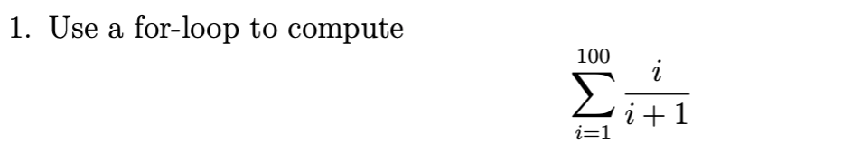

```r
knitr::include_graphics("/Users/terrylu/Desktop/UF/fall/R and Matlab/R/Assgnments/Git/UF-ECO-7938/2/2.1.png")
```

```r
z <- 0                 # initial sum = 0
for (i in 1:100) {     # set up the loop
  t <- i / (i + 1)     # t is the scalar of every components
  z <- z + t
}
z                      # return the sum
```

```
## [1] 95.80272
```

#### 2

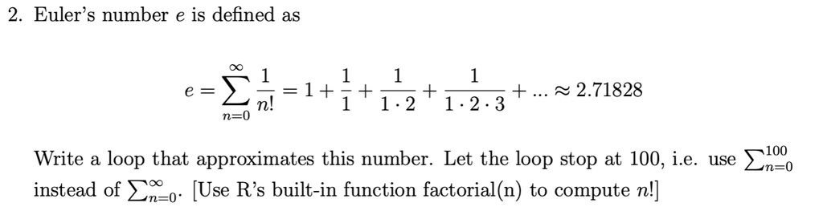

```r
knitr::include_graphics("/Users/terrylu/Desktop/UF/fall/R and Matlab/R/Assgnments/Git/UF-ECO-7938/2/2.2.png")
```

```r
z <- 0                     # initial sum = 0
for (i in 0:100) {         # set up the loop
  z = z + 1/(factorial(i)) # calculate the sum of every components
}
z                          # return the sum
```

```
## [1] 2.718282
```

#### 3.

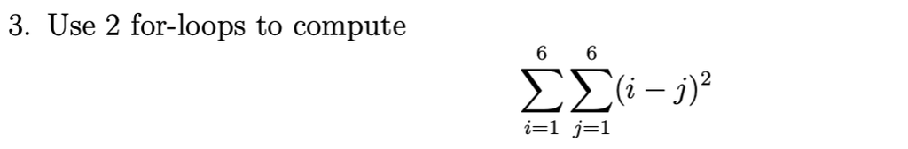

```r
knitr::include_graphics("/Users/terrylu/Desktop/UF/fall/R and Matlab/R/Assgnments/Git/UF-ECO-7938/2/2.3.png")
```

```r
z <- 0                     # initial sum = 0
for (i in 1:6) {           # set up the loop of i
  for (j in 1:6) {         # set up the loop of j which is under loop i
    z = z + (i - j)^2      # calculate the sum of every components
  }
}
z                          # return the sum
```

```
## [1] 210
```

#### 4.

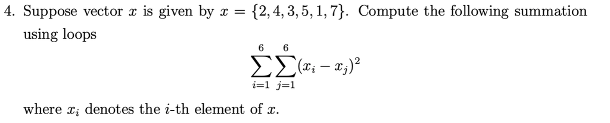

```r
knitr::include_graphics("/Users/terrylu/Desktop/UF/fall/R and Matlab/R/Assgnments/Git/UF-ECO-7938/2/2.4.png")
```

```r
sum_sum <- function(x){             # set up the function which can slove the problem similar to above
  z <- 0                            # initial sum = 0
  for (i in 1:length(x)) {          # set up the double loops
    for (j in 1:length(x)) {
      z <- z + (x[i] - x[j])^2      # calculate the sum of every components
    }
  }
  z                                 # return the sum
}

x = c(2, 4, 3, 5, 1, 7)             # calculate with the function
sum_sum(x)
```

```
## [1] 280
```

### **3 Recessions [30 points]**

#### 1

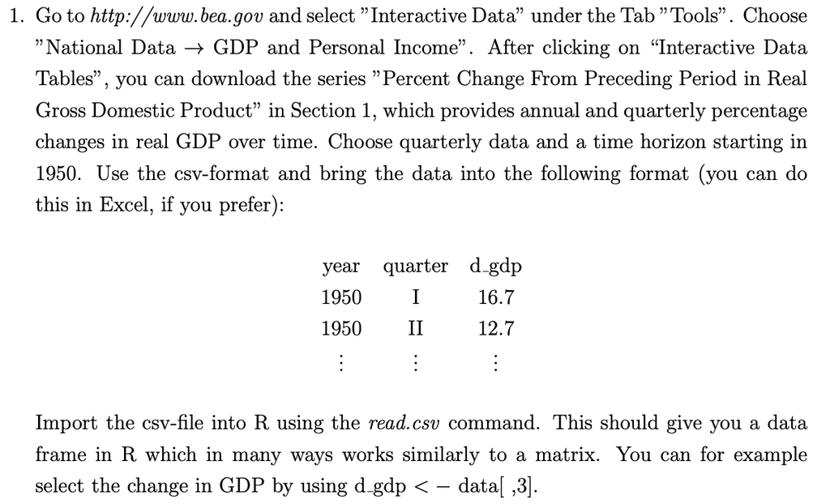

```r
knitr::include_graphics("/Users/terrylu/Desktop/UF/fall/R and Matlab/R/Assgnments/Git/UF-ECO-7938/2/3.1.png")
```

```r
library(data.table)
dt <- read.csv("/Users/terrylu/Desktop/UF/fall/R and Matlab/R/Assgnments/Git/UF-ECO-7938/2/Table.csv", header = FALSE)
dt <- as.data.table(dt)
dt_t <- t(dt)                      # insert the data and invert

year <- dt_t[-1,1]                 #choose the principle variables
quarter <- dt_t[-1,2]
d_gdp <- (dt_t[-1,3])

data <- cbind(year, quarter, d_gdp) # set up the matrix data which contains the principle variables
data[data == "Q1"] <- "I"          # Q1 to be replaced by "I"
data[data == "Q2"] <- "II"         # similarly
data[data == "Q3"] <- "III"
data[data == "Q4"] <- "IX"

data_1 <- as.data.table(data)

head(data_1)
```

```
##      year quarter  d_gdp
##    <char>  <char> <char>
## 1:   1950       I   16.7
## 2:   1950      II   12.7
## 3:   1950     III   16.4
## 4:   1950      IX    7.9
## 5:   1951       I    5.5
## 6:   1951      II    7.1
```

#### 2

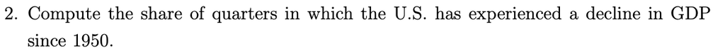

```r
knitr::include_graphics("/Users/terrylu/Desktop/UF/fall/R and Matlab/R/Assgnments/Git/UF-ECO-7938/2/3.2.png")
```

```r
k <- 0                              # set up initial counting factor
for (i in 1:(nrow(data))) {       # set up the loop
  if (data[i,3] < 0) {    # count the times of sequential seasonal gdp < current season
    k <- k+1
  }
}
print(paste("experienced", k, "declines"))
```

```
## [1] "experienced 40 declines"
```

```r
s <- k/(nrow(data))               # calculation the share
print(paste("share is", s))
```

```
## [1] "share is 0.134228187919463"
```

#### 3

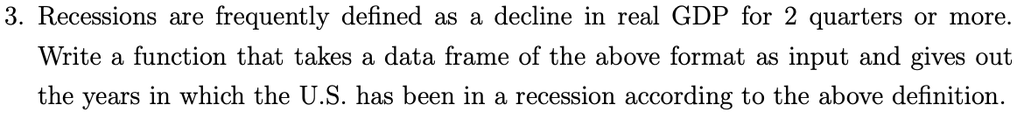

```r
knitr::include_graphics("/Users/terrylu/Desktop/UF/fall/R and Matlab/R/Assgnments/Git/UF-ECO-7938/2/3.3.png")
```

```r
recession <- function(x){         # build up the function
  x_1 <- cbind(data, res = 0)     # set up a assistant dummy variable: res, initially = 0
  x_1 <- as.data.table(x_1)       # Problem !!!!!!!!!!!!!!!!!!!!!
  for (i in 1:(nrow(x_1)-1)) {    # set up the loop
    if (x_1[i,3] < 0) {           # set up the first condition: first decline
      if (x_1[i+1,3] < 0){        # set up the second condition: second decline
        x_1[i,4] <- 1             # if the observation satisfy the both condition, res =1
        x_1[i+1,4] <- 1
      }
    }
  }
  data_res <- x_1[res == 1]       # only keep the observation which satisfy the conditions.
  data_res_year <- data_res[, .SD[1], by = year]   #remove the repeated one
  data_res_year$year              # return the years
}
recession(data)                   # test
```

```
##  [1] "1953" "1954" "1957" "1958" "1969" "1970" "1974" "1975" "1980" "1981"
## [11] "1982" "1990" "1991" "2008" "2009" "2020" "2022"
```

The question asks us to *“give out the year,”* but a recession is a phased period that can span across years. For example, a recession might occur from the fourth quarter of 1990 to the first quarter of 1991. So, I am confused about whether I should mention the former year, the latter year, or both. In the end, I decided to mention both.

In summary, *if the recession starts in the fourth quarter of 1990 and ends in the first quarter of 1991, my result will mention both 1990 and 1991.*